# proj1

```python
import warnings
warnings.simplefilter(action='ignore', category=FutureWarning)
warnings.simplefilter(action='ignore', category=DeprecationWarning)

import numpy as np
import pandas as pd
import seaborn as sns
import sklearn as sk
```

Introduction

The following data was pulled from data.gov at https://catalog.data.gov/dataset/water-quality-data-41c5e/resource/c013c8da-49d3-4898-93a5-f6c0f0e95a0d. It describes the Back Bay Water Quality

```python
watq = pd.read_csv('waterqual.csv')
watq
```

|  | Site_Id | Unit_Id | Read_Date | Salinity (ppt) | Dissolved Oxygen (mg/L) | pH (standard units) | Secchi Depth (m) | Water Depth (m) | Water Temp (?C) | Air Temp-Celsius | Air Temp (?F) | Time (24:00) | Field_Tech | DateVerified | WhoVerified | AirTemp (C) | Year |
| --- | --- | --- | --- | --- | --- | --- | --- | --- | --- | --- | --- | --- | --- | --- | --- | --- | --- |
| 0 | Bay | NaN | 1/3/1994 | 1.3 | 11.7 | 7.3 | 0.40 | 0.40 | 5.9 | 8.0 | 46.40 | 11:00 | NaN | NaN | NaN | 8.000000 | 1994 |
| 1 | Bay | NaN | 1/31/1994 | 1.5 | 12.0 | 7.4 | 0.20 | 0.35 | 3.0 | 2.6 | 36.68 | 11:30 | NaN | NaN | NaN | 2.600000 | 1994 |
| 2 | Bay | NaN | 2/7/1994 | 1.0 | 10.5 | 7.2 | 0.25 | 0.60 | 5.9 | 7.6 | 45.68 | 9:45 | NaN | NaN | NaN | 7.600000 | 1994 |
| 3 | Bay | NaN | 2/23/1994 | 1.0 | 10.1 | 7.4 | 0.35 | 0.50 | 10.0 | 2.7 | 36.86 | NaN | NaN | NaN | NaN | 2.700000 | 1994 |
| 4 | Bay | NaN | 2/28/1994 | 1.0 | 12.6 | 7.2 | 0.20 | 0.40 | 1.6 | 0.0 | 32.00 | 10:30 | NaN | NaN | NaN | 0.000000 | 1994 |
| ... | ... | ... | ... | ... | ... | ... | ... | ... | ... | ... | ... | ... | ... | ... | ... | ... | ... |
| 2366 | Bay | NaN | 10/11/2018 | 1.9 | 5.0 | 7.0 | 4.00 | 1.20 | 25.0 | NaN | 78.00 | 09:30 | Sue Poe | 11/13/2019 | Christine Folks | 25.555556 | 2018 |
| 2367 | Bay | NaN | 10/24/2018 | 0.0 | 9.0 | 7.0 | 0.30 | 0.60 | 18.0 | NaN | 58.00 | 09:30 | Sue Poe | 11/13/2019 | Christine Folks | 14.444444 | 2018 |
| 2368 | Bay | NaN | 10/28/2018 | 0.9 | 2.9 | 7.0 | 0.40 | 0.90 | 13.0 | NaN | 49.00 | 09:20 | Sue Poe | 11/13/2019 | Christine Folks | 9.444444 | 2018 |
| 2369 | Bay | NaN | 11/7/2018 | 1.7 | NaN | 7.0 | 0.45 | 0.90 | 20.0 | NaN | 65.00 | 09:45 | Sue Poe | 11/13/2019 | Christine Folks | 18.333333 | 2018 |
| 2370 | Bay | NaN | 12/11/2018 | 0.1 | NaN | 7.0 | 0.10 | 0.10 | 10.0 | NaN | 42.00 | 09:40 | Sue Poe | 11/13/2019 | Christine Folks | 5.555556 | 2018 |

2371 rows × 17 columns

Preprocessing

Next we drop some columns so we can look at site id, salinity, dissolved oxygen, ph, secchi depth, water depth, water temp, and year. Then, eliminate rows with NaN values

```python
watq = watq.drop(columns=['Unit_Id','Read_Date','Field_Tech', 'DateVerified', 'WhoVerified','AirTemp (C)', 'Air Temp-Celsius', 'Air Temp (?F)', 'Time (24:00)'], axis=1)
watq = watq.dropna()
watq
```

|  | Site_Id | Salinity (ppt) | Dissolved Oxygen (mg/L) | pH (standard units) | Secchi Depth (m) | Water Depth (m) | Water Temp (?C) | Year |
| --- | --- | --- | --- | --- | --- | --- | --- | --- |
| 0 | Bay | 1.3 | 11.7 | 7.3 | 0.40 | 0.40 | 5.9 | 1994 |
| 1 | Bay | 1.5 | 12.0 | 7.4 | 0.20 | 0.35 | 3.0 | 1994 |
| 2 | Bay | 1.0 | 10.5 | 7.2 | 0.25 | 0.60 | 5.9 | 1994 |
| 3 | Bay | 1.0 | 10.1 | 7.4 | 0.35 | 0.50 | 10.0 | 1994 |
| 4 | Bay | 1.0 | 12.6 | 7.2 | 0.20 | 0.40 | 1.6 | 1994 |
| ... | ... | ... | ... | ... | ... | ... | ... | ... |
| 2361 | D | 0.0 | 6.0 | 6.5 | 0.70 | 1.20 | 26.0 | 2018 |
| 2364 | D | 0.0 | 6.9 | 6.5 | 0.90 | 1.30 | 20.0 | 2018 |
| 2366 | Bay | 1.9 | 5.0 | 7.0 | 4.00 | 1.20 | 25.0 | 2018 |
| 2367 | Bay | 0.0 | 9.0 | 7.0 | 0.30 | 0.60 | 18.0 | 2018 |
| 2368 | Bay | 0.9 | 2.9 | 7.0 | 0.40 | 0.90 | 13.0 | 2018 |

1320 rows × 8 columns

Below is a boxplot grouped by Site_Id according to salinity

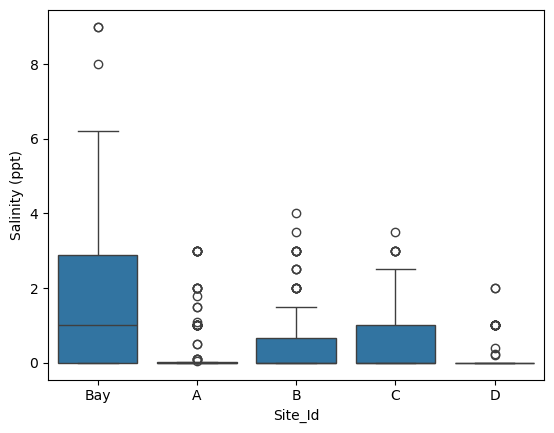

```python
sns.boxplot(x='Site_Id', y='Salinity (ppt)', data=watq)
```

Finding the number of outliers according to Site Id

```python
def is_outlier(x):
    Q25, Q75 = x.quantile([.25,.75])
    I = Q75 - Q25
    return ((x < (Q25 - 1.5*I)) |  (x > (Q75 + 1.5*I)))

outliers = watq.groupby("Site_Id")['Salinity (ppt)'].transform(is_outlier)
q = watq.loc[outliers, 'Site_Id'].value_counts()

print(q)
```

```
Site_Id
A      40
B      18
D      18
C       6
Bay     3
Name: count, dtype: int64
```

Dissolved oxygen analysis

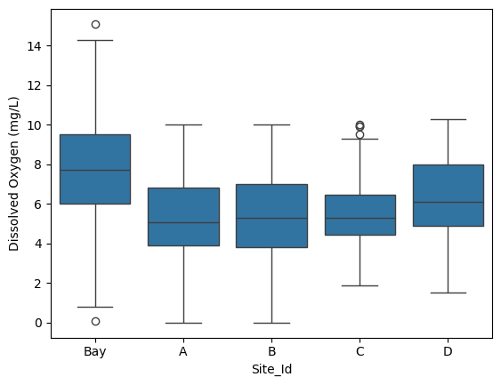

```python
sns.boxplot(x='Site_Id', y='Dissolved Oxygen (mg/L)', data=watq)
```

```python
outliers = watq.groupby("Site_Id")['Dissolved Oxygen (mg/L)'].transform(is_outlier)
q = watq.loc[outliers, 'Site_Id'].value_counts()

print(q)
```

```
Site_Id
C      4
Bay    2
Name: count, dtype: int64
```

pH analysis

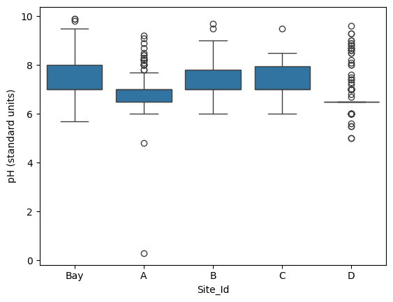

```python
sns.boxplot(x='Site_Id', y='pH (standard units)', data=watq)
```

```python
outliers = watq.groupby("Site_Id")['pH (standard units)'].transform(is_outlier)
q = watq.loc[outliers, 'Site_Id'].value_counts()

print(q)
```

```
Site_Id
D      77
A      25
Bay     3
B       2
C       1
Name: count, dtype: int64
```

Secchi depth analysis

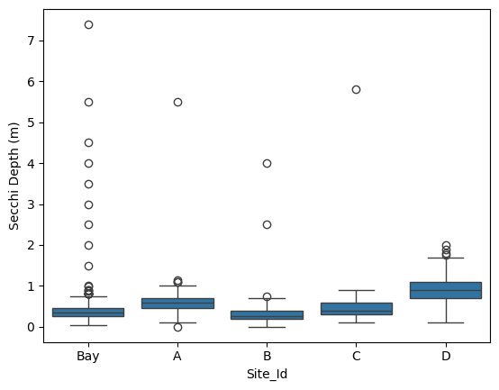

```python
sns.boxplot(x='Site_Id', y='Secchi Depth (m)', data=watq)
```

```python
outliers = watq.groupby("Site_Id")['Secchi Depth (m)'].transform(is_outlier)
q = watq.loc[outliers, 'Site_Id'].value_counts()

print(q)
```

```
Site_Id
Bay    22
A       5
D       4
B       3
C       1
Name: count, dtype: int64
```

Water depth analysis

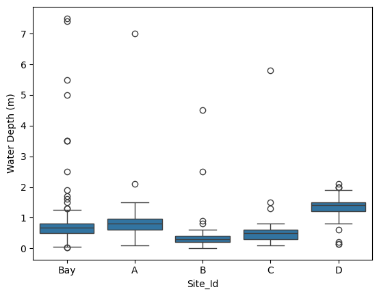

```python
sns.boxplot(x='Site_Id', y='Water Depth (m)', data=watq)
```

```python
outliers = watq.groupby("Site_Id")['Water Depth (m)'].transform(is_outlier)
q = watq.loc[outliers, 'Site_Id'].value_counts()

print(q)
```

```
Site_Id
Bay    16
D       8
B       4
C       3
A       2
Name: count, dtype: int64
```

Water temp analysis

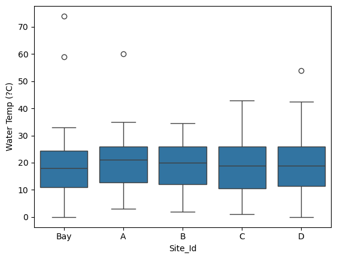

```python
sns.boxplot(x='Site_Id', y='Water Temp (?C)', data=watq)
```

```python
outliers = watq.groupby("Site_Id")['Water Temp (?C)'].transform(is_outlier)
q = watq.loc[outliers, 'Site_Id'].value_counts()

print(q)
```

```
Site_Id
Bay    2
A      1
D      1
Name: count, dtype: int64
```

Further outlier analysis

```python
watq.describe()
```

|  | Salinity (ppt) | Dissolved Oxygen (mg/L) | pH (standard units) | Secchi Depth (m) | Water Depth (m) | Water Temp (?C) | Year |
| --- | --- | --- | --- | --- | --- | --- | --- |
| count | 1320.000000 | 1320.000000 | 1320.000000 | 1320.000000 | 1320.000000 | 1320.000000 | 1320.000000 |
| mean | 0.923023 | 6.731606 | 7.211553 | 0.497761 | 0.749390 | 18.026902 | 2005.139394 |
| std | 1.373680 | 2.520411 | 0.807654 | 0.477977 | 0.576336 | 8.302714 | 8.590170 |
| min | 0.000000 | 0.000000 | 0.300000 | 0.000000 | 0.010000 | 0.000000 | 1899.000000 |
| 25% | 0.000000 | 4.800000 | 6.500000 | 0.300000 | 0.442500 | 11.000000 | 1999.000000 |
| 50% | 0.000000 | 6.600000 | 7.000000 | 0.400000 | 0.680000 | 18.900000 | 2006.000000 |
| 75% | 1.500000 | 8.612500 | 7.500000 | 0.600000 | 0.900000 | 25.000000 | 2012.000000 |
| max | 9.000000 | 15.100000 | 9.900000 | 7.400000 | 7.500000 | 74.000000 | 2019.000000 |

Summary Data analysis

Salinity

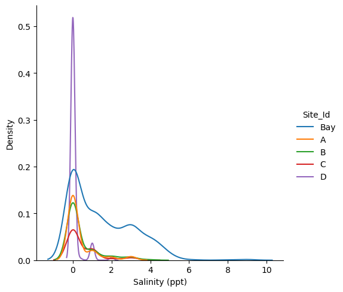

```python
sns.displot(data=watq, x = 'Salinity (ppt)', hue='Site_Id', kind='kde')
```

Dissolved oxygen

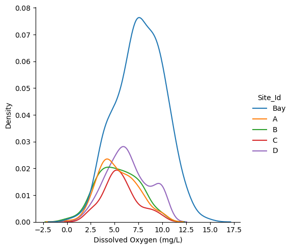

```python
sns.displot(data=watq, x = 'Dissolved Oxygen (mg/L)', hue='Site_Id', kind='kde')
```

pH

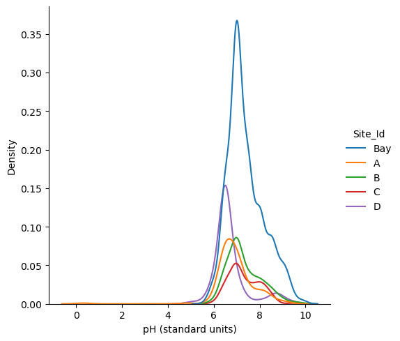

```python
sns.displot(data=watq, x = 'pH (standard units)', hue='Site_Id', kind='kde')
```

Secchi depth

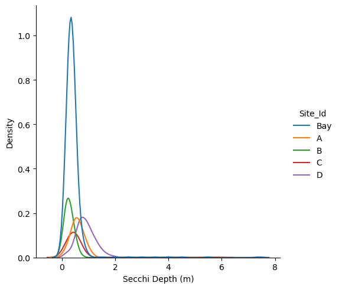

```python
sns.displot(data=watq, x = 'Secchi Depth (m)', hue='Site_Id', kind='kde')
```

Water depth

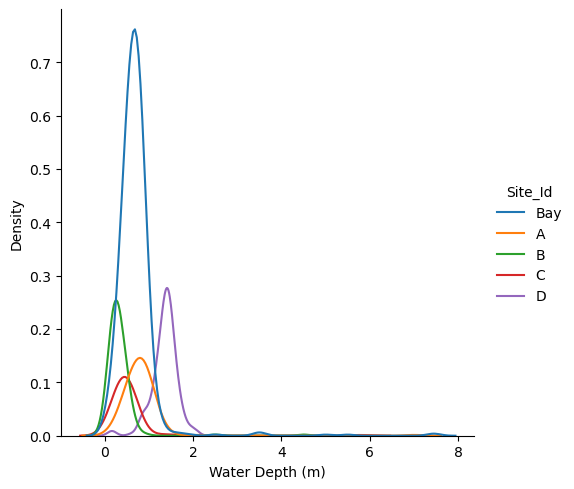

```python
sns.displot(data=watq, x = 'Water Depth (m)', hue='Site_Id', kind='kde')
```

Water temp

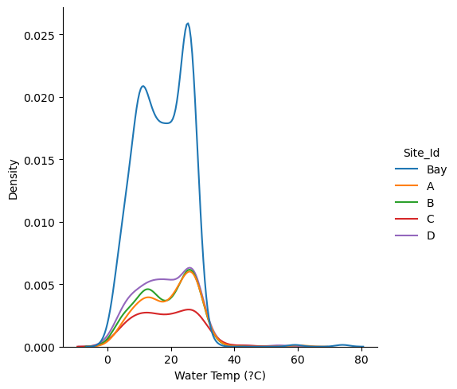

```python
sns.displot(data=watq, x = 'Water Temp (?C)', hue='Site_Id', kind='kde')
```

Now we make a dataframe of Pearson correlation coefficients between all of the columns

```python
cols = watq.columns[1:]
pcorr = watq[cols].corr(method='pearson')
pcorr
```

|  | Salinity (ppt) | Dissolved Oxygen (mg/L) | pH (standard units) | Secchi Depth (m) | Water Depth (m) | Water Temp (?C) | Year |
| --- | --- | --- | --- | --- | --- | --- | --- |
| Salinity (ppt) | 1.000000 | 0.330929 | 0.305956 | -0.151324 | -0.066474 | 0.004317 | -0.626121 |
| Dissolved Oxygen (mg/L) | 0.330929 | 1.000000 | 0.068198 | -0.061994 | -0.017595 | -0.526239 | -0.380029 |
| pH (standard units) | 0.305956 | 0.068198 | 1.000000 | -0.114660 | -0.136254 | 0.181488 | -0.306841 |
| Secchi Depth (m) | -0.151324 | -0.061994 | -0.114660 | 1.000000 | 0.850086 | 0.024603 | 0.146823 |
| Water Depth (m) | -0.066474 | -0.017595 | -0.136254 | 0.850086 | 1.000000 | 0.068967 | 0.041250 |
| Water Temp (?C) | 0.004317 | -0.526239 | 0.181488 | 0.024603 | 0.068967 | 1.000000 | 0.036493 |
| Year | -0.626121 | -0.380029 | -0.306841 | 0.146823 | 0.041250 | 0.036493 | 1.000000 |

Next, finding correlation between dissolved oxygen and water depth

```python
corr = watq.groupby('Site_Id')[['Dissolved Oxygen (mg/L)', 'Water Depth (m)']].corr()
print(corr)
```

```
                                 Dissolved Oxygen (mg/L)  Water Depth (m)
Site_Id
A       Dissolved Oxygen (mg/L)                 1.000000        -0.046860
        Water Depth (m)                        -0.046860         1.000000
B       Dissolved Oxygen (mg/L)                 1.000000         0.049660
        Water Depth (m)                         0.049660         1.000000
Bay     Dissolved Oxygen (mg/L)                 1.000000        -0.072035
        Water Depth (m)                        -0.072035         1.000000
C       Dissolved Oxygen (mg/L)                 1.000000        -0.109684
        Water Depth (m)                        -0.109684         1.000000
D       Dissolved Oxygen (mg/L)                 1.000000         0.100906
        Water Depth (m)                         0.100906         1.000000
```

Next, salinity and pH

```python
corr = watq.groupby('Site_Id')[['Salinity (ppt)', 'pH (standard units)']].corr()
print(corr)
```

```
                             Salinity (ppt)  pH (standard units)
Site_Id
A       Salinity (ppt)             1.000000             0.269008
        pH (standard units)        0.269008             1.000000
B       Salinity (ppt)             1.000000             0.352222
        pH (standard units)        0.352222             1.000000
Bay     Salinity (ppt)             1.000000             0.245911
        pH (standard units)        0.245911             1.000000
C       Salinity (ppt)             1.000000             0.397169
        pH (standard units)        0.397169             1.000000
D       Salinity (ppt)             1.000000            -0.129337
        pH (standard units)       -0.129337             1.000000
```

Secchi depth and water temp

```python
corr = watq.groupby('Site_Id')[['Secchi Depth (m)', 'Water Temp (?C)']].corr()
print(corr)
```

```
                          Secchi Depth (m)  Water Temp (?C)
Site_Id
A       Secchi Depth (m)          1.000000        -0.063283
        Water Temp (?C)          -0.063283         1.000000
B       Secchi Depth (m)          1.000000         0.031976
        Water Temp (?C)           0.031976         1.000000
Bay     Secchi Depth (m)          1.000000         0.119465
        Water Temp (?C)           0.119465         1.000000
C       Secchi Depth (m)          1.000000         0.064327
        Water Temp (?C)           0.064327         1.000000
D       Secchi Depth (m)          1.000000        -0.410634
        Water Temp (?C)          -0.410634         1.000000
```

Discussion

Do pH, salinity, water depth, and water temperature determine which fish live in a body of water?

Can water temperature, pH, salinity, and dissolved oxygen predict clutch survival rates?